Universidad Nacional Autónoma de México - Licenciatura en ciencias genómicas

Introducción a Ciencia de Datos 2021 - Tarea 6

**Salvador González Juárez**

Realizar los siguientes ejercicios.

### 1. Abre el archivo “hersdata_model.csv”.

```r
# Leer el archivo
hersdata_model <- read.table("./hersdata_model.csv", sep = ",", header = T)
setwd("/home/salvador/Documentos/Licenciatura_Ciencias_Genomicas/Cuarto_Semestre/Ciencia_Datos/Tarea_6")

# Eliminar los valores nulos para no tener errores
hersdata_model <- na.omit(hersdata_model)

# Imprimir algunos registros
head(hersdata_model)
```

```
##                HT age raceth nonwhite smoking drinkany exercise
## 1 hormone therapy  77  White       no      no       no      yes
## 2         placebo  78  White       no      no      yes       no
## 3 hormone therapy  66  White       no      no      yes       no
## 4         placebo  61  White       no      no       no      yes
## 5         placebo  55  White       no      no       no      yes
## 6         placebo  70  White       no      no      yes       no
##                physact medcond htnmeds statins diabetes dmpills insulin weight
## 1     much more active       1     yes      no       no      no      no   53.0
## 2     much less active       1      no      no      yes     yes      no  100.0
## 3      about as active       1      no      no       no      no      no   64.2
## 4 somewhat more active       1     yes     yes      yes     yes      no   93.0
## 5 somewhat more active       0     yes      no       no      no      no   68.5
## 6     much more active       1     yes      no       no      no      no   61.5
##     BMI waist   WHR glucose tchol   LDL HDL  TG SBP DBP age10
## 1 23.43  76.0 0.793      91   236 154.0  58 120 157  87   7.7
## 2 37.41 118.2 0.876     131   264 169.0  41 270 140  86   7.8
## 3 25.72  86.0 0.887      92   226 136.2  39 254 139  78   6.6
## 4 32.95 109.0 0.924     238   248 146.2  53 244 114  60   6.1
## 5 29.65  92.5 0.907      93   375 271.0  59 225 185  91   5.5
## 6 24.82  73.0 0.777      89   247 161.4  61 123 118  60   7.0
```

### 2. Ajusta un modelo lineal considerando el peso de las pacientes como la variable de respuesta y la medida de la cintura de las pacientes como variable predictora. Recuerda revisar la normalidad de la variable de respuesta y realizar las transformaciones que sean necesarias. Grafica la variable predictora y la variable de respuesta. Interpreta los resultados.

Primero, voy a revisar que los valores del peso y las medidas de la cintura estén en orden, y si no lo están, tendré que filtrar los registros conservando solo aquellos que no son extraños.

```r
# Resumen de los valores para el peso, la cintura y la edad
summary(hersdata_model$weight)
```

```
##    Min. 1st Qu.  Median    Mean 3rd Qu.    Max.
##   37.50   62.00   71.00   72.55   80.90  132.00
```

```r
summary(hersdata_model$waist)
```

```
##    Min. 1st Qu.  Median    Mean 3rd Qu.    Max.
##   56.90   81.50   90.50   91.52  100.00  150.00
```

Los valores mínimos y máximos corresponden a valores posibles, por lo cual voy a conservar todos los registros. A continuación, voy a evaluar la normalidad de la variable de respuesta y de la variable predictora.

```r
# Importar las librerias requeridas
library(ggplot2)  # Graficas
library(bestNormalize)  # Normalizaciones
```

**Variable de respuesta: peso**

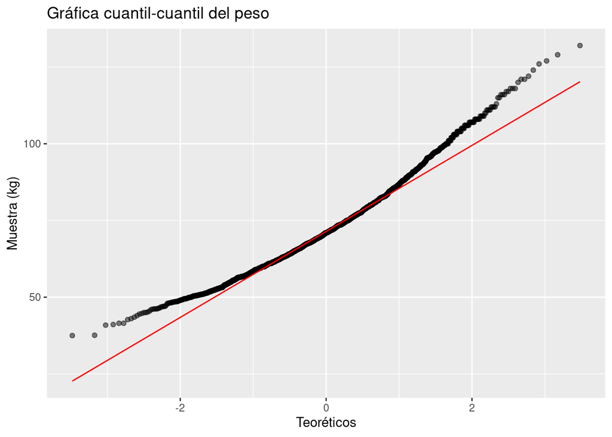

```r
# Grafica cuantil-cuantil del peso
ggplot(hersdata_model, aes(sample = weight)) +
  stat_qq(alpha = 0.5) +
  stat_qq_line(color = "red") +
  labs(title = "Gráfica cuantil-cuantil del peso", x = "Teoréticos", y = "Muestra (kg)")
```

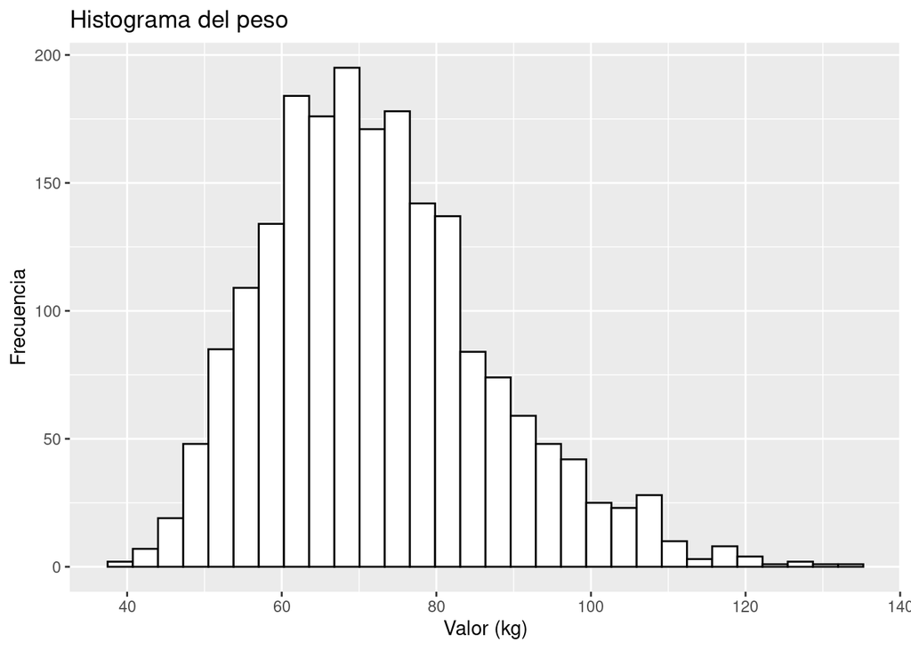

```r
# Histograma del peso
ggplot(hersdata_model, aes(x = weight)) +
  geom_histogram(color = "black", fill = "white") +
  labs(title = "Histograma del peso", x = "Valor (kg)", y = "Frecuencia")
```

```r
# Evaluar la normalidad del peso
ks.test(hersdata_model$weight, pnorm, mean(hersdata_model$weight), sd(hersdata_model$weight))
```

```
##
##  One-sample Kolmogorov-Smirnov test
##
## data:  hersdata_model$weight
## D = 0.0531, p-value = 2.528e-05
## alternative hypothesis: two-sided
```

La gráfica cuantil-cuantil y el histograma del peso nos revelan que el conjunto de valores correspondientes al peso no tienen una distribución normal perfecta, pero sí una muy similar. La prueba contundente de que los datos no están normalizados es el test **Kolmogorov-Smirnov**, ya que el p-valor es menor a 0.05. En consecuencia, los valores del peso deben ser normalizados, pero antes voy a evaluar la normalidad de la variable predictora.

**Variable predictora: circunferencia de la cintura**

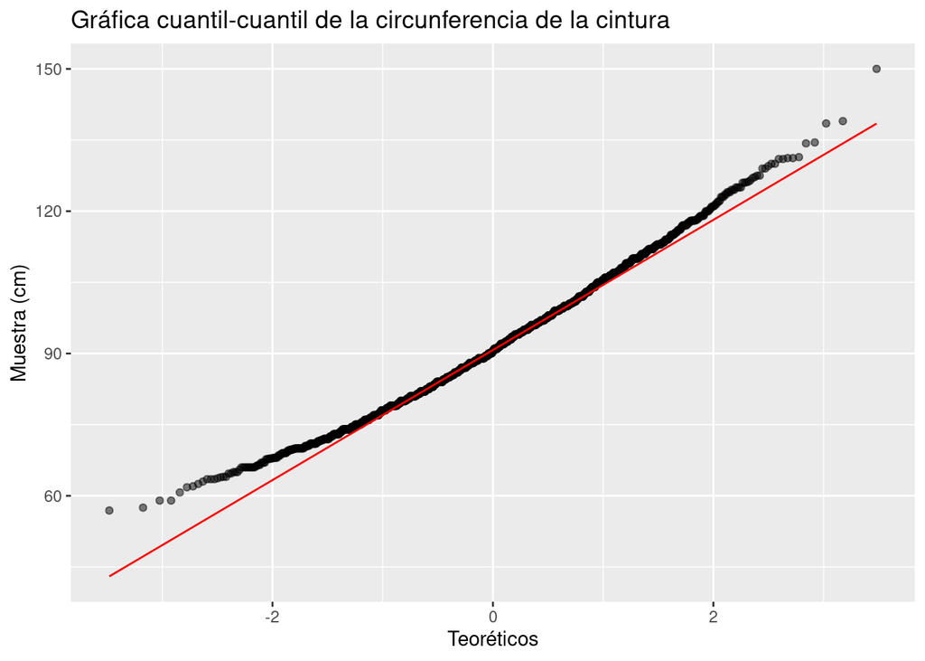

```r
# Grafica cuantil-cuantil de la circunferencia de la cintura
ggplot(hersdata_model, aes(sample = waist)) +
  stat_qq(alpha = 0.5) +
  stat_qq_line(color = "red") +
  labs(title = "Gráfica cuantil-cuantil de la circunferencia de la cintura", x = "Teoréticos", y = "Muestra (cm)")
```

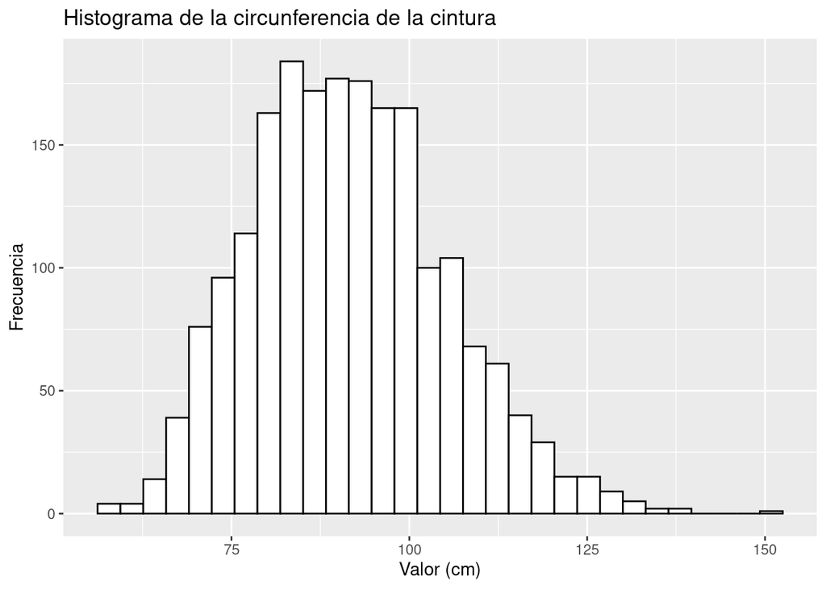

```r
# Histograma de la circunferencia de la cintura
ggplot(hersdata_model, aes(x = waist)) +
  geom_histogram(color = "black", fill = "white") +
  labs(title = "Histograma de la circunferencia de la cintura", x = "Valor (cm)", y = "Frecuencia")
```

```r
# Evaluar la normalidad de la circunferencia de la cintura
ks.test(hersdata_model$waist, pnorm, mean(hersdata_model$waist), sd(hersdata_model$waist))
```

```
##
##  One-sample Kolmogorov-Smirnov test
##
## data:  hersdata_model$waist
## D = 0.040988, p-value = 0.002413
## alternative hypothesis: two-sided
```

Las gráficas y el test de Kolmogorov-Smirnov revelan que los valores de la circunferencia de la cintura no siguen una distribución normal, pero sí una muy similar. No es necesario normalizar los valores de la variable predictora, por lo que sólo voy a normalizar los valores de la variable de respuesta. Es necesario buscar un método óptimo para normalizar los datos.

**Normalización**

```r
# Buscar el mejor metodo de normalizacion
set.seed(8)
bestnorm <- bestNormalize(hersdata_model$weight)
print(bestnorm)
```

```
## Best Normalizing transformation with 2000 Observations
##  Estimated Normality Statistics (Pearson P / df, lower => more normal):
##  - arcsinh(x): 0.9915
##  - Box-Cox: 1.0259
##  - Center+scale: 1.6758
##  - Exp(x): 224.1049
##  - Log_b(x+a): 0.9915
##  - orderNorm (ORQ): 1.1568
##  - sqrt(x + a): 1.184
##  - Yeo-Johnson: 1.0298
## Estimation method: Out-of-sample via CV with 10 folds and 5 repeats
##
## Based off these, bestNormalize chose:
## Standardized asinh(x) Transformation with 2000 nonmissing obs.:
##  Relevant statistics:
##  - mean (before standardization) = 4.957773
##  - sd (before standardization) = 0.1979831
```

Ahora que sé que método de normalización usar, voy a evaluar la normalidad de los valores normalizados de la variable de respuesta.

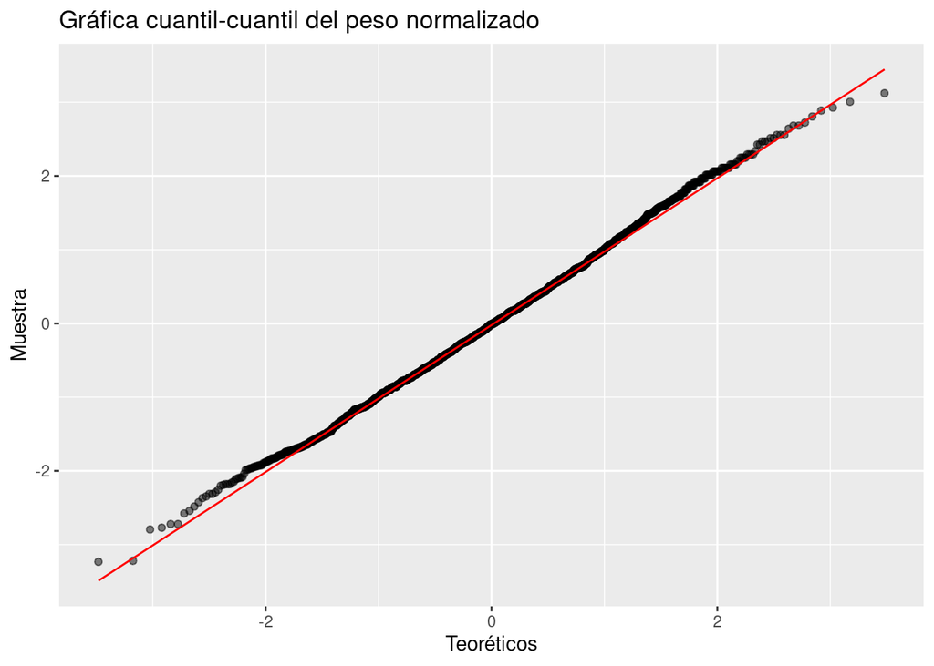

```r
# Almacenar los datos normalizados
hersdata_model$weight_norm <- bestnorm$x.t

# Grafica cuantil-cuantil del peso normalizado
ggplot(hersdata_model, aes(sample = weight_norm)) +
  stat_qq(alpha = 0.5) +
  stat_qq_line(color = "red") +
  labs(title = "Gráfica cuantil-cuantil del peso normalizado", x = "Teoréticos", y = "Muestra")
```

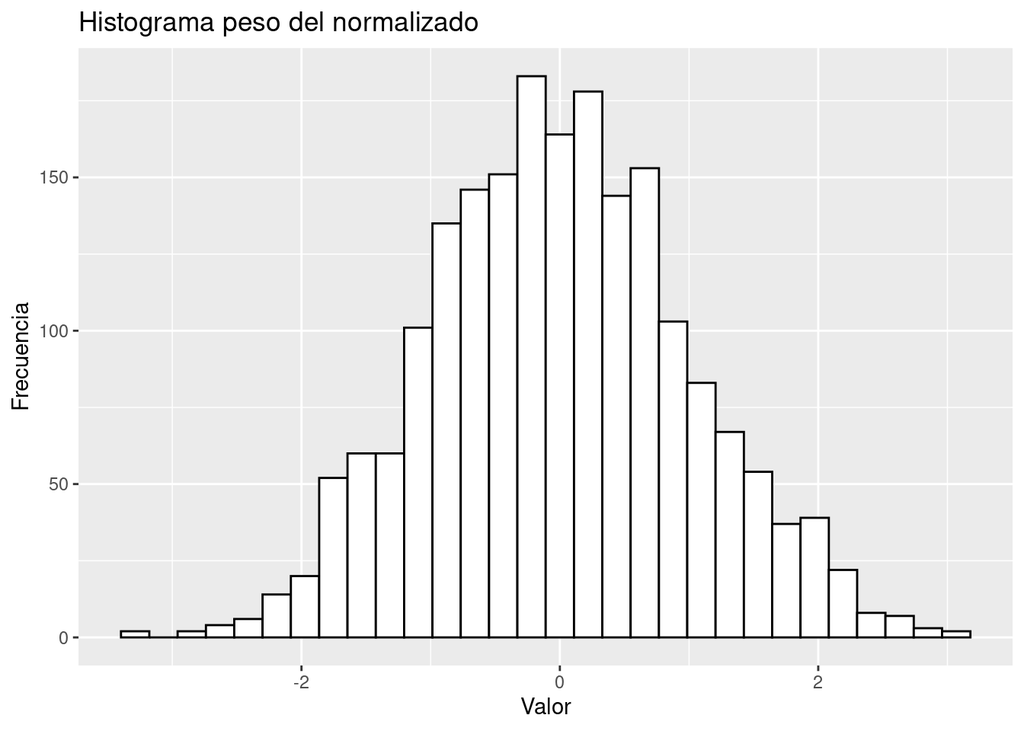

```r
# Histograma del peso normalizado
ggplot(hersdata_model, aes(x = weight_norm)) +
  geom_histogram(color = "black", fill = "white") +
  labs(title = "Histograma peso del normalizado", x = "Valor", y = "Frecuencia")
```

```r
# Evaluar la normalidad del peso normalizado
ks.test(hersdata_model$weight_norm, pnorm, mean(hersdata_model$weight_norm), sd(hersdata_model$weight_norm))
```

```
##
##  One-sample Kolmogorov-Smirnov test
##
## data:  hersdata_model$weight_norm
## D = 0.015206, p-value = 0.7442
## alternative hypothesis: two-sided
```

Una vez que los valores del peso han sido normalizados las gráficas demuestran una total normalidad, la cual es confirmada por el p-valor mayor a 0.05 en el test Kolmogorov-Smirnov. Ahora es posible continuar con la generación del modelo.

**Ajuste del modelo**

```r
# Ajustar el modelo para dos variables
modelo <- lm(data = hersdata_model, weight_norm ~ waist)
summary(modelo)
```

```
##
## Call:
## lm(formula = weight_norm ~ waist, data = hersdata_model)
##
## Residuals:
##      Min       1Q   Median       3Q      Max
## -2.91649 -0.32924  0.01093  0.32375  2.96203
##
## Coefficients:
##               Estimate Std. Error t value Pr(>|t|)
## (Intercept) -5.7547246  0.0789734  -72.87   <2e-16 ***
## waist        0.0628802  0.0008536   73.67   <2e-16 ***
## ---
## Signif. codes:  0 '***' 0.001 '**' 0.01 '*' 0.05 '.' 0.1 ' ' 1
##
## Residual standard error: 0.5189 on 1998 degrees of freedom
## Multiple R-squared:  0.7309, Adjusted R-squared:  0.7308
## F-statistic:  5427 on 1 and 1998 DF,  p-value: < 2.2e-16
```

Del resumen del modelo se puede rescatar algunos datos importantes. Primero, el p-valor menor a 0.05 demuestra que sí hay una relación entre la circunferencia de la cintura y el peso. Además, la R² ajustada indica que el modelo es relativamente bueno, pero que podría ser mejor. Por último, voy a graficar la regresión lineal entre ambas variables.

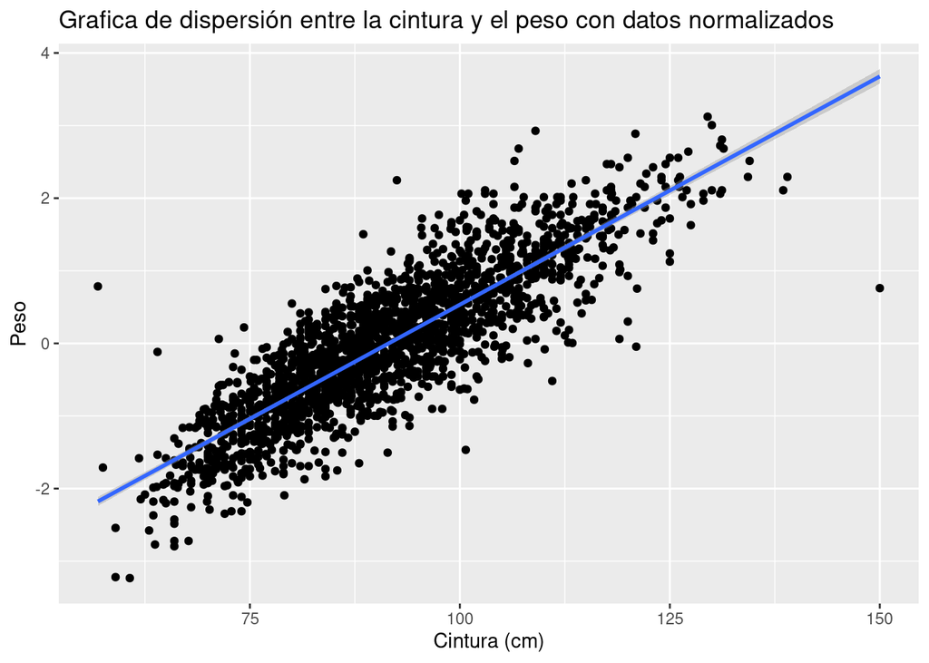

```r
# Graficar la regresion lineal
ggplot(hersdata_model, aes(waist, weight_norm)) +
  geom_point() +
  geom_smooth(method = lm) +
  labs(title = "Grafica de dispersión entre la cintura y el peso con datos normalizados", x = "Cintura (cm)", y = "Peso")
```

Se puede observar en la gráfica anterior que hay una tendencia de aumentar de peso cuando la circunferencia de la cintura incrementa. Sin embargo hay una dispersión importante a lo largo de la regresión, lo cual puede ser explicado por otros factores, además de la circunferencia de la cintura, que influyen en la determinación del peso de la persona.

### 3. Considerando el modelo predicho anteriormente, realiza la gráfica de la diferencia entre los valores observados y los esperados. Grafica los residuales contra los índices y verifica que éstos sean normales. Realiza un histograma y haz pruebas de normalidad. Interpreta los resultados.

Para verificar si el modelo es bueno, es necesario graficar la distancia que existe entre nuestras observaciones y los valores esperados (es decir, los residuales).

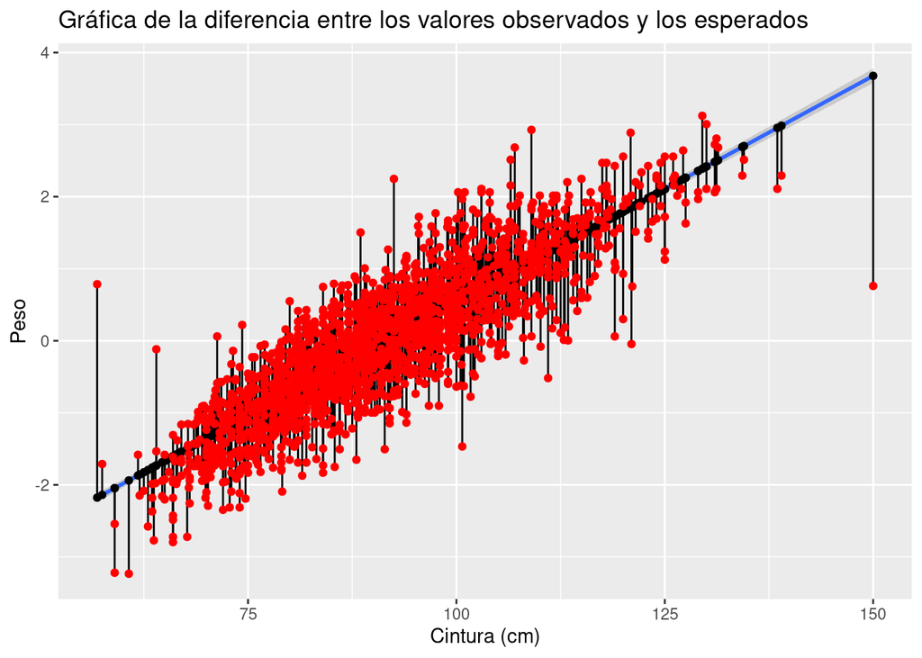

```r
# Almacenar los residuales y valores esperados del modelo
hersdata_model$residuals <- modelo$residuals
hersdata_model$predicted <- modelo$fitted.values

# Graficar la diferencia entre los valores observados y los esperados
ggplot(hersdata_model, aes(x = waist, y = weight_norm)) +
  geom_smooth(method = lm) +
  geom_segment(aes(xend = waist, yend = predicted)) +
  geom_point(aes(y = predicted)) +
  geom_point(color = "red") +
  labs(title = "Gráfica de la diferencia entre los valores observados y los esperados", x = "Cintura (cm)", y = "Peso")
```

En la gráfica anterior se observa como la dispersión de los valores del peso se alejan relativamente de los valores esperados, lo cual reitera mi observación previa de que hay más factores que influyen en el peso. A continuación, voy a evaluar la calidad del modelo graficando únicamente los residuales.

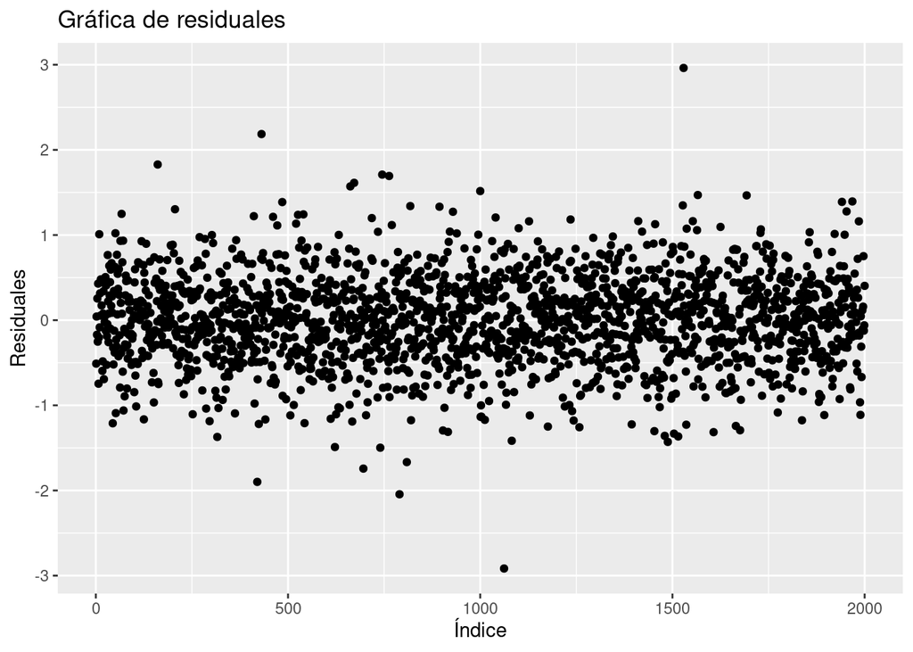

```r
# Almacenar los indices de cada valor
hersdata_model$index <- 1:nrow(hersdata_model)

# Graficar los residuales
ggplot(hersdata_model, aes(x = index, y = residuals)) +
  geom_point() +
  labs(title = "Gráfica de residuales", x = "Índice", y = "Residuales")
```

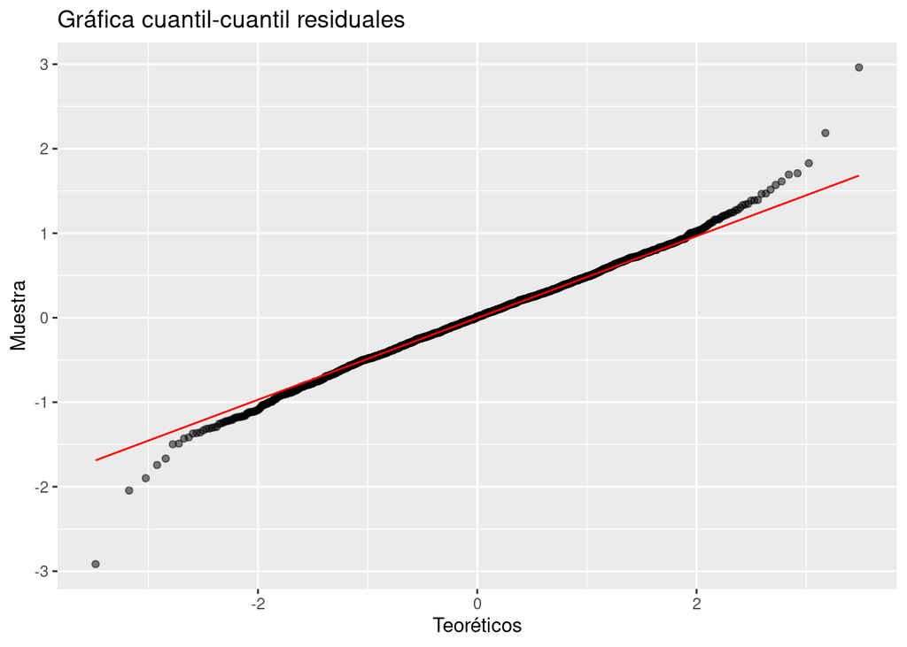

```r
# Grafica cuantil-cuantil de los residuales
ggplot(hersdata_model, aes(sample = residuals)) +
  stat_qq(alpha = 0.5) +
  stat_qq_line(color = "red") +
  labs(title = "Gráfica cuantil-cuantil residuales", x = "Teoréticos", y = "Muestra")
```

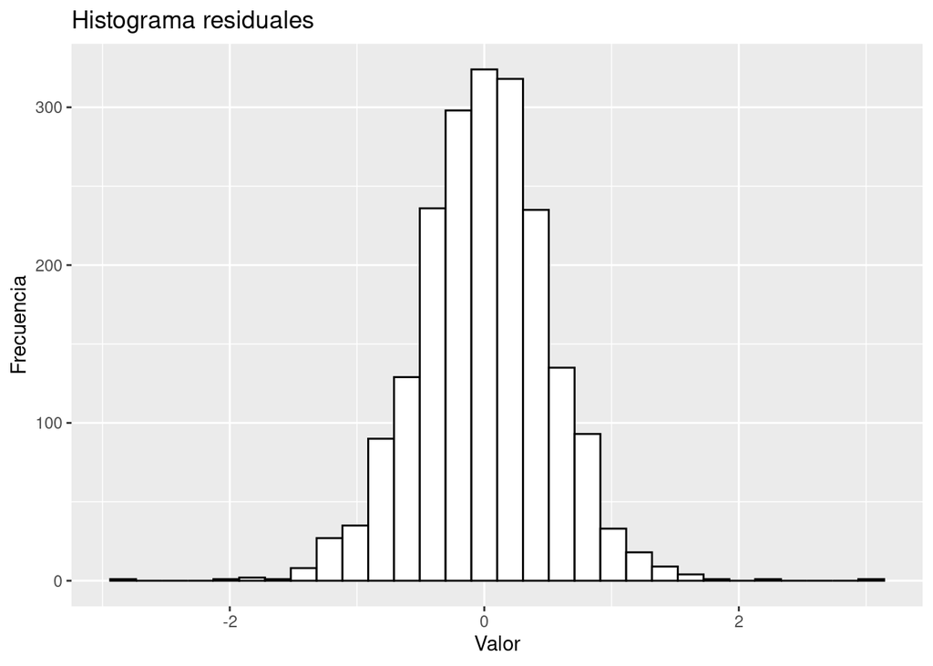

```r
# Histograma de los residuales
ggplot(hersdata_model, aes(x = residuals)) +
  geom_histogram(color = "black", fill = "white") +
  labs(title = "Histograma residuales", x = "Valor", y = "Frecuencia")
```

```r
# Evaluar la normalidad de los residuales
ks.test(hersdata_model$residuals, pnorm, mean(hersdata_model$residuals), sd(hersdata_model$residuals))
```

```
##
##  One-sample Kolmogorov-Smirnov test
##
## data:  hersdata_model$residuals
## D = 0.01924, p-value = 0.4496
## alternative hypothesis: two-sided
```

Tanto las gráficas, como el test Kolmogorov-Smirnov, comprueban que los residuales siguen una distribución normal. Por lo tanto, todo indica a que el modelo fue hecho de forma correcta y tiene posibilidades de tener un potencial predictivo. Sin embargo, no considero que el modelo sea demasiado bueno, ya que como se dijo anteriormente, existen otros factores que el modelo no esta considerando, pero que son importantes en la determinación del peso de una persona. Esto tiene sentido ya que otras partes del cuerpo pueden crecer en volumen, aumentando el peso, pero sin incrementar la circunferencia de la cintura.

### 4. Predice los valores de peso para personas con las medidas de cintura presentes en el archivo “hersdata_predictions.csv”. Si realizaste una transformación de la variable de respuesta, recuerda devolver los valores a la escala original.

```r
# Leer y filtrar los valores del archivo
hersdata_pred <- read.table("./hersdata_predictions.csv", sep = ",", header = T)
hersdata_pred <- na.omit(hersdata_pred)

# Imprimir algunos registros
head(hersdata_pred)
```

```
##                HT age           raceth nonwhite smoking drinkany exercise
## 1         placebo  64            White       no     yes      yes       no
## 2 hormone therapy  68 African American      yes      no      yes       no
## 3         placebo  70            White       no      no       no       no
## 4 hormone therapy  62            White       no     yes      yes       no
## 5 hormone therapy  73            White       no      no       no       no
## 6 hormone therapy  57            White       no     yes       no       no
##                physact medcond htnmeds statins diabetes dmpills insulin weight
## 1     much less active       1     yes      no       no      no      no   64.4
## 2      about as active       0      no      no       no      no      no   60.9
## 3      about as active       0      no      no      yes      no     yes   89.3
## 4 somewhat less active       0     yes      no       no      no      no  112.0
## 5 somewhat more active       1     yes      no       no      no      no   73.2
## 6 somewhat less active       0     yes      no       no      no      no   68.6
##     BMI waist   WHR glucose tchol   LDL HDL  TG SBP DBP age10
## 1 24.39  87.0 0.877      94   204 116.2  56 159 152  72   6.4
## 2 29.05  96.0 1.000     116   212 137.8  52 111 174  98   6.8
## 3 34.45 114.5 0.974     120   314 228.8  33 261 119  61   7.0
## 4 45.68 139.7 0.933      98   303 220.0  40 215 111  71   6.2
## 5 25.27  93.0 0.886      95   201 123.8  47 151 158  84   7.3
## 6 28.12  95.0 0.941     109   259 153.4  49 283 182  95   5.7
```

Una vez que he identificado los valores del peso y de la circunferencia de la cintura, voy a usar estos últimos para intentar predecir el peso correspondiente.

```r
# Predecir el valor del peso con el valor de la circunferencia de la cintura
pred_results <- predict(bestnorm, newdata = predict(modelo, newdata = data.frame(waist = hersdata_pred$waist)), inverse = TRUE)
head(pred_results)
```

```
## [1]  67.24312  75.21637  94.69827 129.59693  72.45877  74.28570
```

A continuación, voy a analizar la precisión del modelo considerando si los valores predichos del peso se acercan a los valores reales del peso.

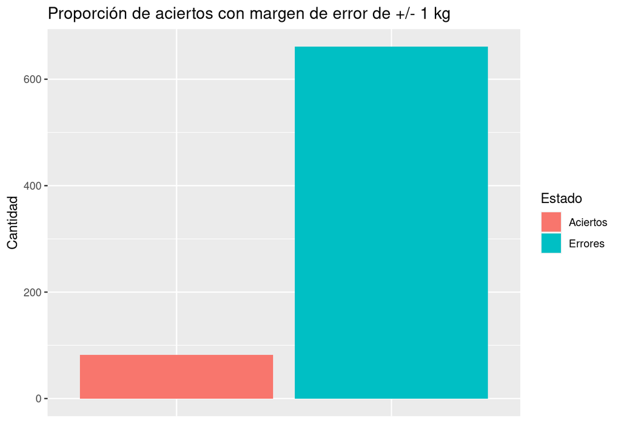

```r
# Esta funcion grafica la proporcion de aciertos y errores del modelo
comparar <- function(x, y, n){
  count <- 0
  total <- length(x)
  for (i in 1:total) {
    if ((x[i] < y[i] + n) & (x[i] > y[i] - n)) {
      count =+ count + 1
    }
  }

  # Dibujar una grafica de barras
  ggplot(data.frame(Var1 = c("Aciertos", "Errores"), Freq = c(count, total - count)), aes(x = Var1, y = Freq, fill = Var1)) +
    geom_bar(stat = "identity") +
    theme(axis.ticks.x = element_blank(), axis.text.x=element_blank()) +
    scale_fill_discrete(name = "Estado", labels = c("Aciertos", "Errores")) +
    labs(title = paste("Proporción de aciertos con margen de error de +/-", as.character(n), "kg", sep = " "), x = "", y = "Cantidad")
}

# Evaluar la precision del modelo con ciertos margenes de error
comparar(pred_results, hersdata_pred$weight, 1)
```

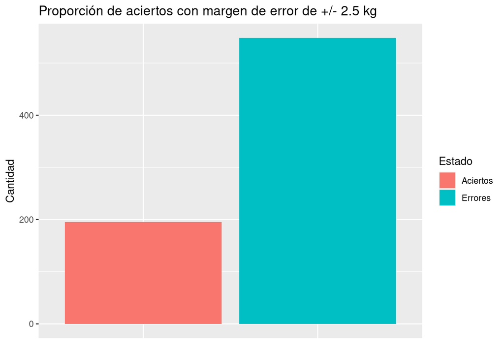

```r
comparar(pred_results, hersdata_pred$weight, 2.5)
```

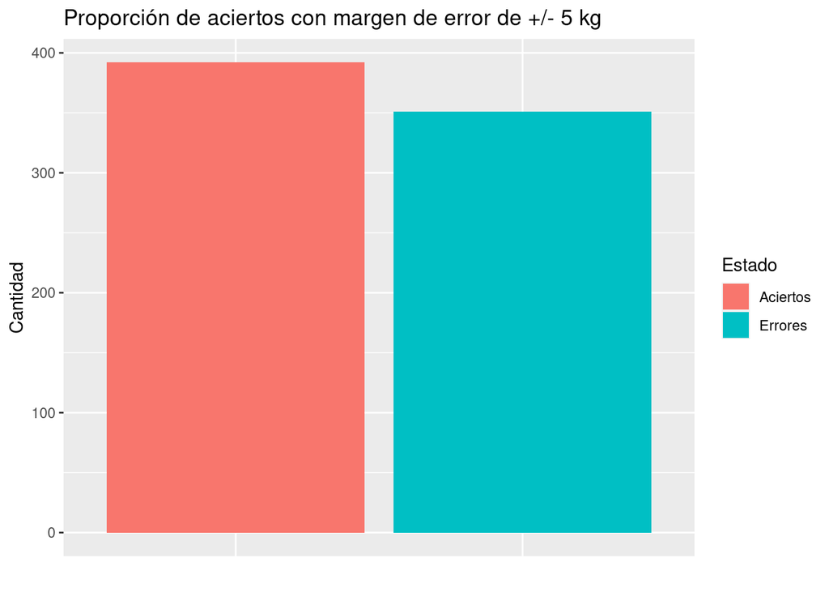

```r
comparar(pred_results, hersdata_pred$weight, 5)
```

En las gráficas anteriores se puede observar que el modelo no es muy preciso, ya que alcanza poco más de la mitad de aciertos únicamente cuando el margen de error es de +/- 5 kg, lo cual, tomando en cuenta el rango de los valores del peso, demuestra el modelo predictivo es poco informativo. En conclusión, hay una clara tendencia a incrementar el peso cuando aumenta la circunferencia, pero esta medida no es útil para predecir los valores del peso, pues hay muchos más factores biológicos que influyen en el peso de una persona.

### 5. Ajusta un modelo lineal múltiple para el peso contra las siguientes variables: age, raceth, smoking, drinkany, exercise, medcond, htnmeds, statins, diabetes, dmpills, insulin, waist, glucose, LDL, HDL, TG, SBP y DBP. Interpreta los resultados devueltos por summary(). No es posible realizar una gráfica para visualizar todas las variables, pero puedes apoyarte de gráficas individuales para tus interpretaciones (tip: compara las gráficas obtenidas con el peso y variables significativas contra las gráficas obtenidas con el peso y variables no significativas).

Ya tengo los valores normalizados de la variable de respuesta, por lo que se puede continuar con el análisis. Como son varias variables predictoras, no voy a evaluar su normalidad y voy a confiar en que no hay errores en sus valores. A continuación, voy a ajustar el modelo con múltiples variables.

```r
# Ajustar el modelo para multiples variables
modelo_multiple <- lm(data = hersdata_model, weight_norm ~ age + raceth + smoking + drinkany + exercise + medcond + htnmeds + statins + diabetes + dmpills + insulin + waist + glucose + LDL + HDL + TG + SBP + DBP)
summary(modelo_multiple)
```

```
##
## Call:
## lm(formula = weight_norm ~ age + raceth + smoking + drinkany +
##     exercise + medcond + htnmeds + statins + diabetes + dmpills +
##     insulin + waist + glucose + LDL + HDL + TG + SBP + DBP, data = hersdata_model)
##
## Residuals:
##      Min       1Q   Median       3Q      Max
## -2.86330 -0.31078  0.00669  0.30794  2.91607
##
## Coefficients:
##               Estimate Std. Error t value Pr(>|t|)
## (Intercept) -4.9097758  0.4120249 -11.916  < 2e-16 ***
## age         -0.0157740  0.0018703  -8.434  < 2e-16 ***
## racethOther -0.2992425  0.0761766  -3.928 8.85e-05 ***
## racethWhite -0.0623938  0.0437826  -1.425   0.1543
## smokingyes  -0.2181266  0.0354925  -6.146 9.60e-10 ***
## drinkanyno   0.3851293  0.3573045   1.078   0.2812
## drinkanyyes  0.4143232  0.3573559   1.159   0.2464
## exerciseyes -0.0381487  0.0237880  -1.604   0.1089
## medcond     -0.0118265  0.0237975  -0.497   0.6193
## htnmedsyes   0.0058305  0.0299232   0.195   0.8455
## statinsyes   0.0308562  0.0242561   1.272   0.2035
## diabetesyes -0.0574659  0.0449869  -1.277   0.2016
## dmpillsyes   0.0250230  0.0501666   0.499   0.6180
## insulinyes   0.0850038  0.0503796   1.687   0.0917 .
## waist        0.0611879  0.0009395  65.130  < 2e-16 ***
## glucose     -0.0002613  0.0004299  -0.608   0.5433
## LDL          0.0007287  0.0003168   2.300   0.0215 *
## HDL         -0.0009091  0.0009752  -0.932   0.3513
## TG          -0.0002237  0.0002033  -1.100   0.2715
## SBP         -0.0011840  0.0007379  -1.605   0.1087
## DBP          0.0031436  0.0014184   2.216   0.0268 *
## ---
## Signif. codes:  0 '***' 0.001 '**' 0.01 '*' 0.05 '.' 0.1 ' ' 1
##
## Residual standard error: 0.5024 on 1979 degrees of freedom
## Multiple R-squared:  0.7501, Adjusted R-squared:  0.7476
## F-statistic:   297 on 20 and 1979 DF,  p-value: < 2.2e-16
```

```r
# Importar una libreria para codificar
library(qdap)
```

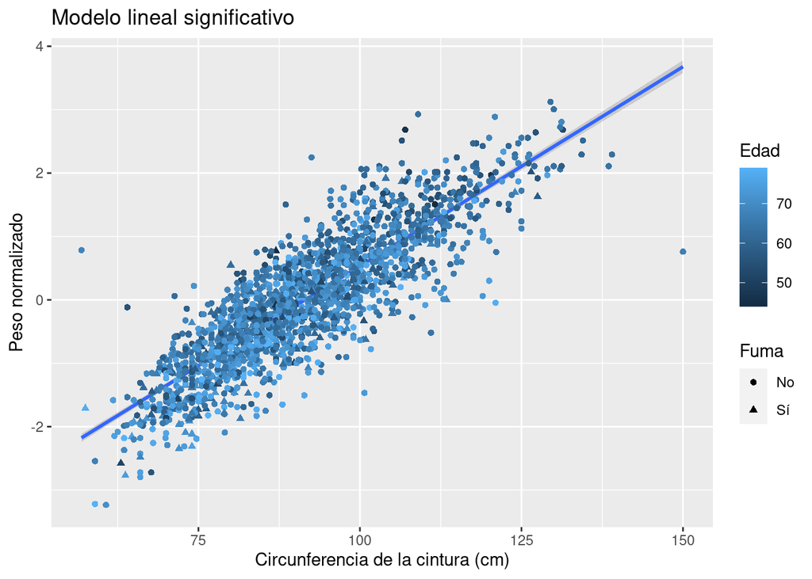

```r
# Cambiar el idioma de los valores de la categoria fumador
hersdata_model$smoking <- multigsub(sort(unique(hersdata_model$smoking)), c("No", "Sí"), hersdata_model$smoking)

# Graficar la relacion entre variables significativas
ggplot(hersdata_model, aes(x = waist, y = weight_norm, color = age)) +
  geom_smooth(method = lm) +  # añadimos la linea de regresion
  geom_point(aes(shape = as.factor(smoking))) +  # agregamos los puntos de las observaciones en color rojo
  labs(title = "Modelo lineal significativo", x = "Circunferencia de la cintura (cm)", y = "Peso normalizado", color = "Edad", shape = "Fuma")
```

Grafiqué en conjunto las variables de edad, si la persona fuma y la circunferencia de la cintura porque están muy relacionadas con el peso. Omiti la variable sobre la raza porque considero que era muy poco informativa y las dimensiones de la gráfica ya no permitían otra variable más. Se puede observar en la gráfica la misma tendencia de que al incrementar la circunferencia de la cintura aumenta el peso. Además, aparentemente hay más personas que fuman con pesos bajos que con pesos altos. Finalmente, me es difícil visualizar como está relacionada la edad con el peso.

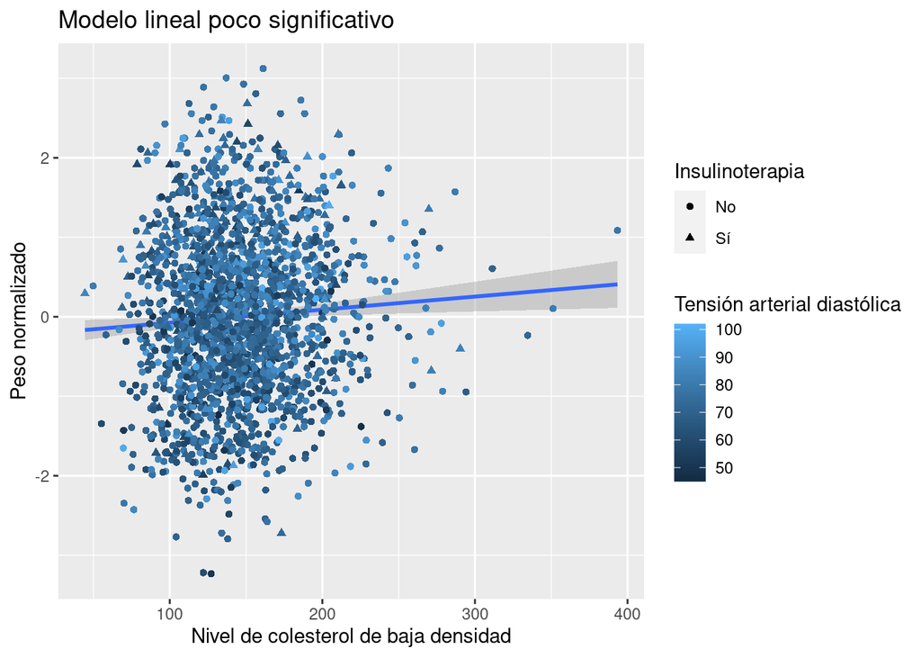

```r
# Cambiar el idioma de los valores de la categoria insulina
hersdata_model$insulin <- multigsub(sort(unique(hersdata_model$insulin)), c("No", "Sí"), hersdata_model$insulin)

# Graficar la relacion entre variables poco significativas
ggplot(hersdata_model, aes(x = LDL, y = weight_norm, color = DBP)) +
  geom_smooth(method = lm) +  # añadimos la linea de regresion
  geom_point(aes(shape = as.factor(insulin))) +  # agregamos los puntos de las observaciones en color rojo
  labs(title = "Modelo lineal poco significativo", x = "Nivel de colesterol de baja densidad", y = "Peso normalizado", color = "Tensión arterial diastólica", shape = "Insulinoterapia")
```

Grafiqué en conjunto las variables de nivel de colesterol de baja densidad, si la persona está tomando una inulinoterapia y la tensión arterial diastólica porque están ligeramente relacionadas con el peso. Se puede observar en la gráfica que no hay una tendencia entre el aumento del peso y la dispersión de los valores del nivel de colesterol. Además, me es difícil visualizar un patrón que relacione la tensión arterial diatólica y la inmunoterapia con el peso.

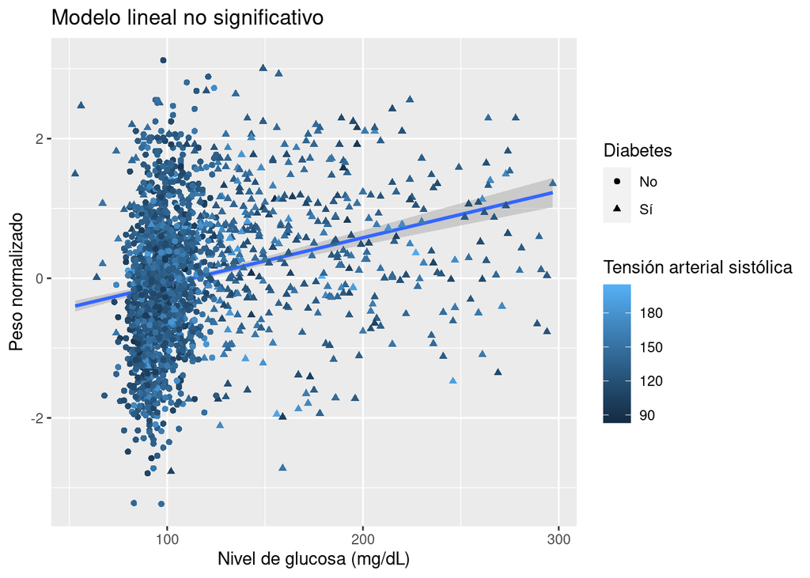

```r
# Cambiar el idioma de los valores de la categoria diabetes
hersdata_model$diabetes <- multigsub(sort(unique(hersdata_model$diabetes)), c("No", "Sí"), hersdata_model$diabetes)

# Graficar la relacion entre no significativas
ggplot(hersdata_model, aes(x = glucose, y = weight_norm, color = SBP)) +
  geom_smooth(method = lm) +  # añadimos la linea de regresion
  geom_point(aes(shape = as.factor(diabetes))) +  # agregamos los puntos de las observaciones en color rojo
  labs(title = "Modelo lineal no significativo", x = "Nivel de glucosa (mg/dL)", y = "Peso normalizado", color = "Tensión arterial sistólica", shape = "Diabetes")
```

### 6. Grafica los residuales contra los índices. Realiza un histograma y haz pruebas de normalidad. Interpreta los resultados.

Para evaluar la calidad del modelo múltiple voy a graficar únicamente los residuales y a verificar que los residuales sigan una distribución normal.

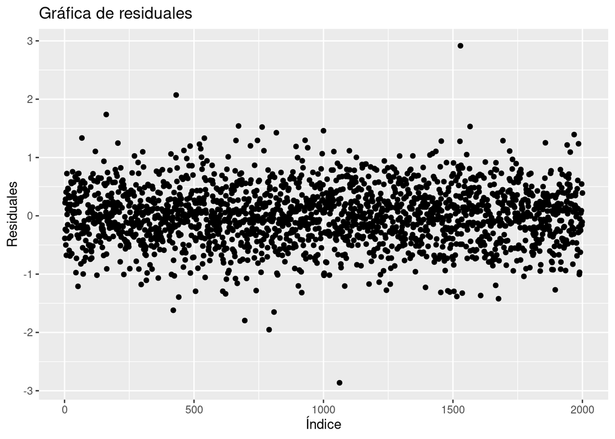

```r
# Guardar los residuales del modelo multiple
hersdata_model$residuals2 <- modelo_multiple$residuals

# Graficar los residuales del modelo multiple
ggplot(hersdata_model, aes(x = index, y = residuals2)) +
  geom_point() +
  labs(title = "Gráfica de residuales", x = "Índice", y = "Residuales")
```

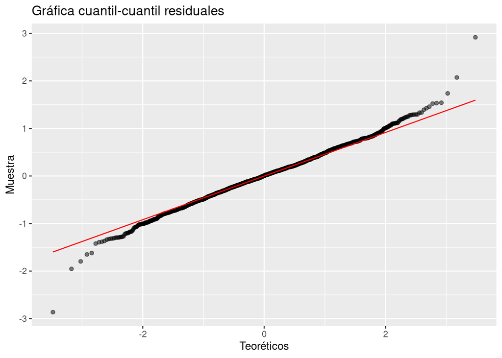

```r
# Grafica cuantil-cuantil de los residuales del modelo multiple
ggplot(hersdata_model, aes(sample = residuals2)) +
  stat_qq(alpha = 0.5) +
  stat_qq_line(color = "red") +
  labs(title = "Gráfica cuantil-cuantil residuales", x = "Teoréticos", y = "Muestra")
```

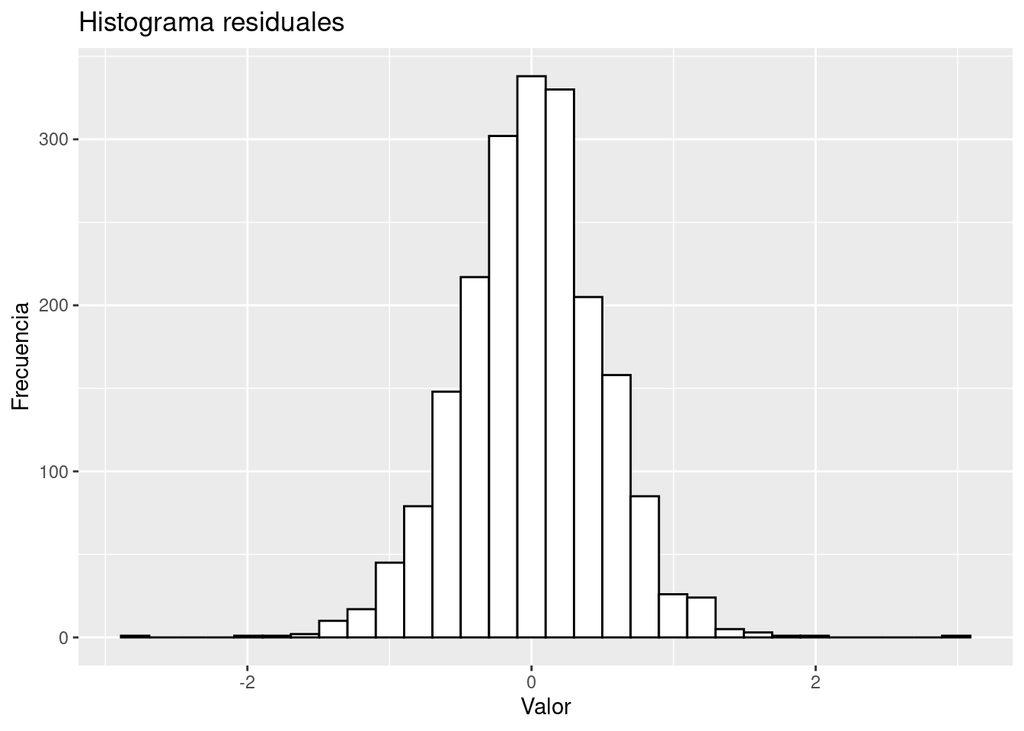

```r
# Histograma de los residuales del modelo multiple
ggplot(hersdata_model, aes(x = residuals2)) +
  geom_histogram(color = "black", fill = "white") +
  labs(title = "Histograma residuales", x = "Valor", y = "Frecuencia")
```

```r
# Evaluar la normalidad de los residuales
ks.test(hersdata_model$residuals2, pnorm, mean(hersdata_model$residuals2), sd(hersdata_model$residuals2))
```

```
##
##  One-sample Kolmogorov-Smirnov test
##
## data:  hersdata_model$residuals2
## D = 0.023604, p-value = 0.2151
## alternative hypothesis: two-sided
```

La dispersión de los residuales no es totalmente aleatoria, ya que de nuevo los puntos tienden a agruparse en el eje horizontal. Esto podría indicar que existe un patron escondido que el modelo lineal no esta considerando. La gráfica cuantil-cuantil y el histograma de los residuales, asi como el test Kolmogorov-Smirnov, comprueban que los residuales siguen una distribución normal. Por lo tanto, todo indica a que el modelo fue hecho de forma correcta y tiene posibilidades de tener un potencial predictivo. Sin embargo, otra vez no considero que el modelo sea demasiado bueno, ya que los nuevos factores que el modelo esta considerando no parecen dar más información que pueda ser determinante en la predicción del peso. Esto tiene sentido ya que el peso puede incrementar o descender dependiendo de la combinación de muchos factores, incluso más allá de los que fueron considerados en este modelo múltiple.

### 7. Predice los valores de peso para todas las variables usando el archivo “hersdata_predictions.csv”. Si realizaste una transformación de la variable de respuesta, recuerda devolver los valores a la escala original.

A continuación, voy a analizar la precisión del modelo múltiple considerando si los valores predichos del peso se acercan a los valores reales del peso.

```r
# Preparar los valores de las multiples variables
newdata <- data.frame(age = hersdata_pred$age,
  raceth = hersdata_pred$raceth,
  smoking = hersdata_pred$smoking,
  drinkany = hersdata_pred$drinkany,
  exercise = hersdata_pred$exercise,
  medcond = hersdata_pred$medcond,
  htnmeds = hersdata_pred$htnmeds,
  statins = hersdata_pred$statins,
  diabetes = hersdata_pred$diabetes,
  dmpills = hersdata_pred$dmpills,
  insulin = hersdata_pred$insulin,
  waist = hersdata_pred$waist,
  glucose = hersdata_pred$glucose,
  LDL = hersdata_pred$LDL,
  HDL = hersdata_pred$HDL,
  TG = hersdata_pred$TG,
  SBP = hersdata_pred$SBP,
  DBP = hersdata_pred$DBP)

# Predecir el valor del peso con el valor de multiples variables
pred_results <- predict(bestnorm, newdata = predict(modelo_multiple, newdata = newdata), inverse = TRUE)
head(pred_results)
```

```
## [1]  65.09453  77.08948  94.60690 127.36359  71.30134  73.61367
```

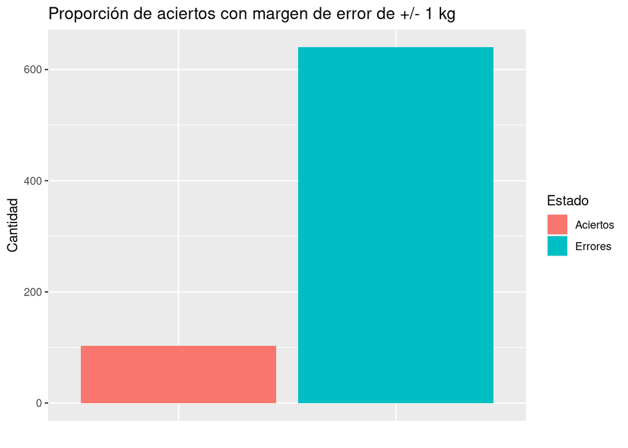

```r
# Evaluar la precision del modelo con ciertos margenes de error
comparar(pred_results, hersdata_pred$weight, 1)
```

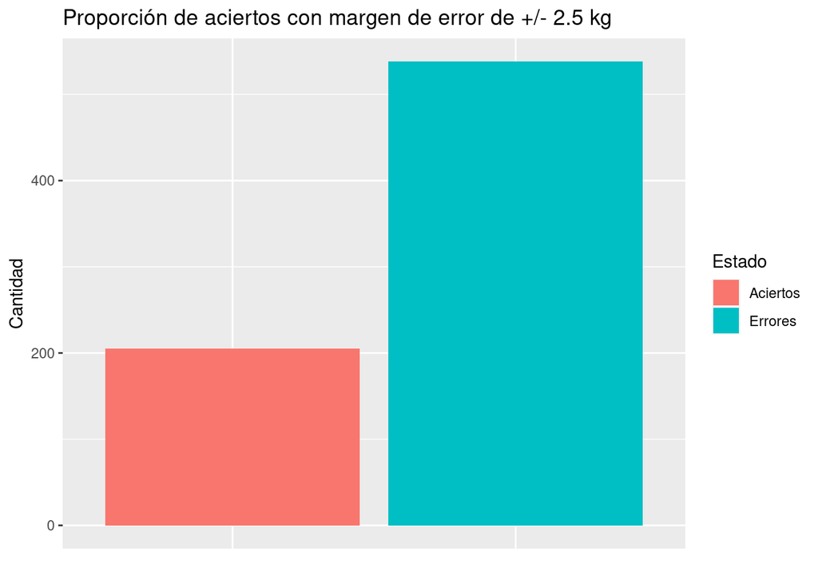

```r
comparar(pred_results, hersdata_pred$weight, 2.5)
```

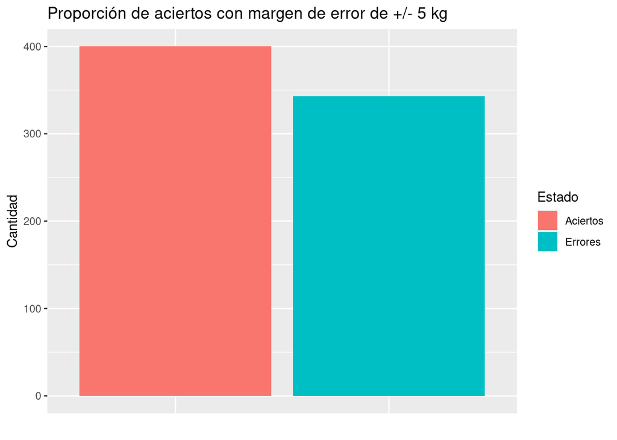

```r
comparar(pred_results, hersdata_pred$weight, 5)
```

En las gráficas anteriores se puede observar que el modelo múltiple tampoco es muy preciso, ya que alcanza poco más de la mitad de aciertos únicamente cuando el margen de error es de +/- 5 kg, lo cual tomando en cuenta el rango de los valores del peso da como resultado un modelo predictivo poco informativo. Cabe señalar que el modelo múltiple si mejoro la precisión del modelo simple, lo cual se debe a la consideración de más variables. En conclusión, hay algunas variables dentro del modelo que si describen alguna tendencia para predecir el peso, pero no es suficiente para predecir con exactitud los valores del peso, pues hay muchos más factores biológicos y combinaciones de variables que influyen en el peso de una persona.

### 8. Ajusta un modelo logístico para la variable diabetes contra la variable glucosa. Grafica la variable predictora y la variable de respuesta. Interpreta los resultados.

```r
# Codificar los valores de diabetes para evitar errores
hersdata_model$diabetes <- multigsub(sort(unique(hersdata_model$diabetes)), c(0, 1), hersdata_model$diabetes)

# Ajustar el modelo logistico
modelo_logistico <- glm(data = hersdata_model, as.numeric(diabetes) ~ glucose, family = "binomial")
summary(modelo_logistico)
```

```
##
## Call:
## glm(formula = as.numeric(diabetes) ~ glucose, family = "binomial",
##     data = hersdata_model)
##
## Deviance Residuals:
##     Min       1Q   Median       3Q      Max
## -1.3406  -0.4325  -0.2700   0.0008   3.8459
##
## Coefficients:
##               Estimate Std. Error z value Pr(>|z|)
## (Intercept) -13.114887   0.625953  -20.95   <2e-16 ***
## glucose       0.107925   0.005654   19.09   <2e-16 ***
## ---
## Signif. codes:  0 '***' 0.001 '**' 0.01 '*' 0.05 '.' 0.1 ' ' 1
##
## (Dispersion parameter for binomial family taken to be 1)
##
##     Null deviance: 2310.8  on 1999  degrees of freedom
## Residual deviance: 1046.2  on 1998  degrees of freedom
## AIC: 1050.2
##
## Number of Fisher Scoring iterations: 7
```

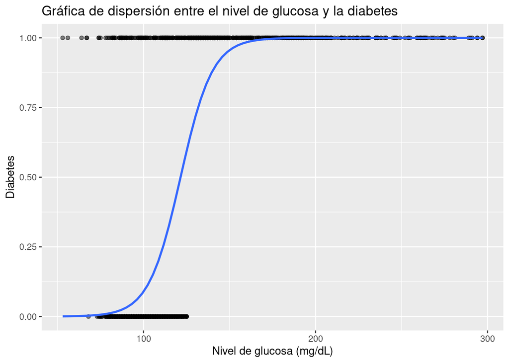

```r
# Graficar la relación entre el nivel de glucosa y la diabetes
ggplot(hersdata_model, aes(x = glucose, y = as.numeric(diabetes))) +
  geom_point(alpha=.5) +
  stat_smooth(method = glm, se = FALSE, method.args = list(family = binomial)) +
  labs(title = "Gráfica de dispersión entre el nivel de glucosa y la diabetes", x = "Nivel de glucosa (mg/dL)", y = "Diabetes")
```

En la gráfica anterior se observa que existe una pendiente muy pronunciada, lo cual podría indicar que ambas categorías son significativamente distintas con respecto al nivel de glucosa. Al analizar más a fondo, observo que los individuos que no presentan diabetes tienen niveles de glucosa que se establecen en un rango bajo. Por su parte, aquellas personas que presentan diabetes tienen una distribución muy amplia en el nivel de glucosa, alcanzando incluso niveles en el rango de alto. Por lo tanto, hay una relación entre no tener diabetes y tener niveles bajos de glucosa, pero esta tendencia se vuelve más incierta cuando la persona sí tiene diabetes.

### 9. Calcula la R2 de Hosmer y Lemeshow. ¿Qué tan buena es la variable para predecir la presencia de la enfermedad?

```r
# Calcular la R2 de Hosmer y Lemeshow
(modelo_logistico$null.deviance - modelo_logistico$deviance) / modelo_logistico$null.deviance
```

```
## [1] 0.5472603
```

El valor de la R² de Hosmer y Lemeshow no es muy alto, lo que indica que el nivel de glucosa esta explicando aproximadamente el 0.55 de la varianza total de la variable de respuesta, es decir, la presencia o ausencia de diabetes. Por lo tanto, la variable del nivel de glucosa no es muy buena para predecir la diabetes, ya que como dije previamente, la distribución del nivel de glucosa en una persona con diabetes es muy amplia, y va desde el rango bajo hasta el rango alto, lo cual dificulta la predicción.

### 10. Grafica los residuales contra los índices y verifica que éstos sean normales. Realiza un histograma y haz pruebas de normalidad. Interpreta los resultados.

Para evaluar la calidad del modelo logístico voy a graficar únicamente los residuales y a verificar que los residuales sigan una distribución normal.

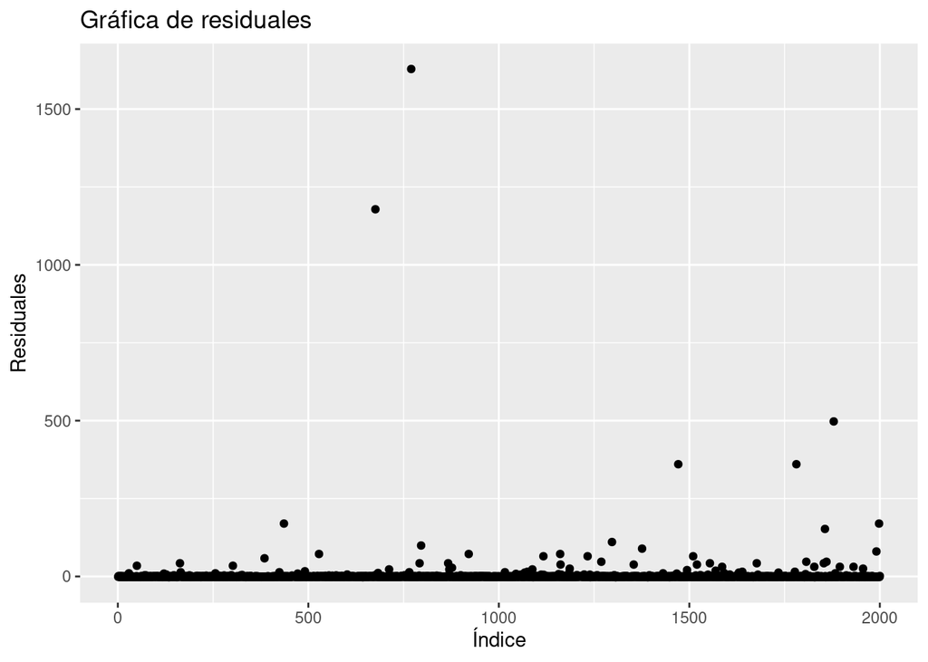

```r
# Guardar los residuales del modelo logistico
hersdata_model$residuals3 <- modelo_logistico$residuals

# Graficar los residuales del modelo logistico
ggplot(hersdata_model, aes(x = index, y = residuals3)) +
  geom_point() +
  labs(title = "Gráfica de residuales", x = "Índice", y = "Residuales")
```

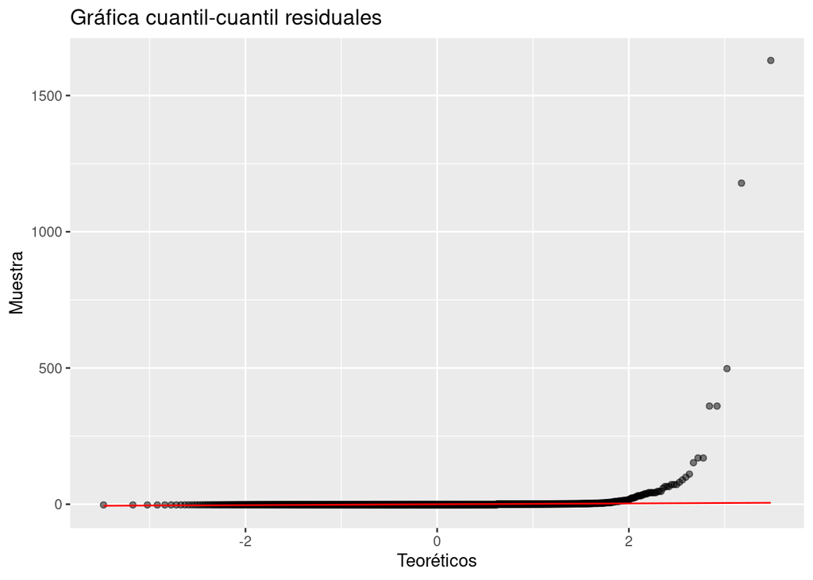

```r
# Grafica cuantil-cuantil de los residuales del modelo logistico
ggplot(hersdata_model, aes(sample = residuals3)) +
  stat_qq(alpha = 0.5) +
  stat_qq_line(color = "red") +
  labs(title = "Gráfica cuantil-cuantil residuales", x = "Teoréticos", y = "Muestra")
```

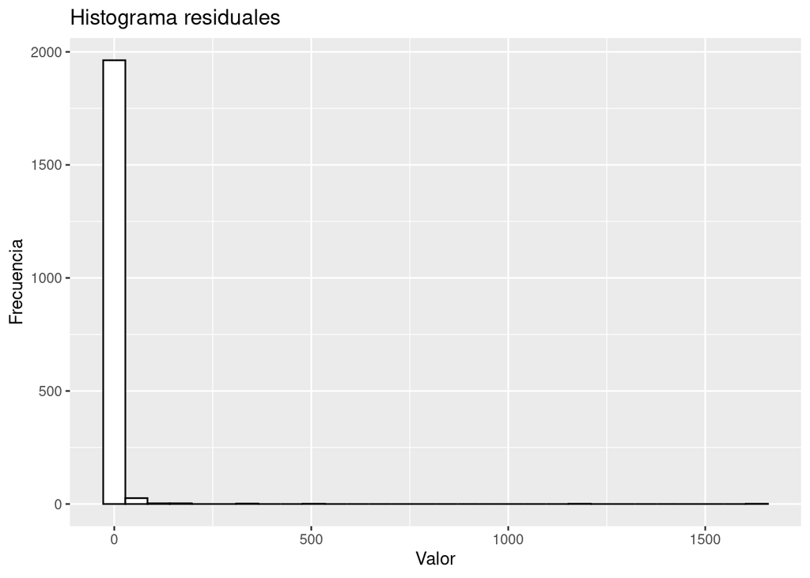

```r
# Histograma de los residuales del modelo logistico
ggplot(hersdata_model, aes(x = residuals3)) +
  geom_histogram(color = "black", fill = "white") +
  labs(title = "Histograma residuales", x = "Valor", y = "Frecuencia")
```

```r
# Evaluar la normalidad de los residuales
ks.test(hersdata_model$residuals3, pnorm, mean(hersdata_model$residuals3), sd(hersdata_model$residuals3))
```

```
##
##  One-sample Kolmogorov-Smirnov test
##
## data:  hersdata_model$residuals3
## D = 0.45716, p-value < 2.2e-16
## alternative hypothesis: two-sided
```

La dispersión de los residuales parece estar siguiendo un patrón donde la mayoría tiene un valor de cero. Yo interpreto esto como un indicio de un patron escondido que el modelo lineal no esta considerando. La gráfica cuantil-cuantil y el histograma de los residuales, asi como el test Kolmogorov-Smirnov, comprueban que los residuales no siguen una distribución normal. Por lo tanto, todo indica a que el modelo no tiene un potencial predictivo. Esto va de acuerdo a mi observación de que el modelo tiene dificultades para diferenciar si una persona tiene diabetes por la amplia distribución del nivel de glucosa que caracteriza a la enfermedad. Esto tiene sentido ya que las personas con diabetes pueden eventualmente controlar sus niveles de glucosa.

### 11. Predice la probabilidad de presentar diabetes para personas con las medidas de glucosa presentes en el archivo “hersdata_predictions.csv”.

```r
# Predecir la diabetes con el valor del nivel de glucosa
pred_results <- predict(modelo_logistico, newdata = data.frame(glucose = hersdata_pred$glucose), type = "response")
summary(pred_results)
```

```
##      Min.   1st Qu.    Median      Mean   3rd Qu.      Max.
## 0.0000461 0.0397036 0.0892846 0.2609657 0.3075808 1.0000000
```

El resumen de la probabilidad de presentar diabetes usando el modelo logístico confirma que no es muy preciso a la hora de predecir la ausencia o presencia de la enfermedad. A pesar de haber casos donde predice con completa seguridad, hay también casos donde la probabilidad es muy baja. El promedio de la probabilidad es de aproximadamente 0.26, lo cual quiere decir que el modelo no es muy bueno prediciendo.